# NA FGO Reddit Survey Jun-Jul 2018

WTByte

29 July 2018

# Introduction

This is a reddit community survey for Fate Grand/Order (FGO) players taken in the June - July 2018 period. The survey focused on the Super Super Rare (SSR) heroic spirits. A total of 4930 submissions were collected.

Data processing/cleaning was conducted before analysis of the data. These included:

1. Removal of blank and NA rows
2. Removal of F2P user with 420 total SSRs with less than 1 month played
3. Merging of the multiple columns for easier data analysis e.g. grouping Sabers together etc.
4. Assuming that blank sex indicated “Prefer not to say”

It is important to consider the bias in the data set. Since it was taken from 3 sources (one of which was reddit), it may not be representative of the whole player base of FGO.

# Spending Demographics

Table 1: Spending of Players

| Spending | Frequency | Percent of Total |
| --- | --- | --- |
| F2P | 1341 | 27.97 |
| Paid Gacha Only | 1451 | 30.27 |
| 1-100 USD monthly | 1238 | 25.82 |
| 100-500 USD monthly | 690 | 14.39 |
| 500+ USD monthly | 74 | 1.54 |

From Table 1, 72.03% of players have spent at least $1 in the game so far. Of the players who have spent money on the game, 42.03% were from paid gacha only, 35.85% spent $1 to $100, 19.98% spent between $100 and $500 per month, and 2.14% spent more than $500.

## Sex

Table 2 to 4 summarises Spending and Sex.

Table 2: Spending vs Sex

|  | Female | Male | Prefer not to say |
| --- | --- | --- | --- |
| F2P | 148 | 1094 | 99 |
| Paid Gacha Only | 125 | 1232 | 94 |
| 1-100 USD monthly | 118 | 1069 | 51 |
| 100-500 USD monthly | 58 | 592 | 40 |
| 500+ USD monthly | 7 | 64 | 3 |

Table 2 contains the frequency for each of the categories of left blank, Female, Male and “Prefer not to say”.

Table 3: Spending vs Sex Conditioning on Spending

|  | Female | Male | Prefer not to say |
| --- | --- | --- | --- |
| F2P | 0.11 | 0.82 | 0.07 |
| Paid Gacha Only | 0.09 | 0.85 | 0.06 |
| 1-100 USD monthly | 0.10 | 0.86 | 0.04 |
| 100-500 USD monthly | 0.08 | 0.86 | 0.06 |
| 500+ USD monthly | 0.09 | 0.86 | 0.04 |

Table 3 displays the proportions of each Sex given they are a certain spender e.g. in F2P, females make up 11% of the total. This means that summing up each row will result in 100%.

Table 4: Spending vs Sex Conditioning on Sex

|  | Female | Male | Prefer not to say |
| --- | --- | --- | --- |
| F2P | 0.32 | 0.27 | 0.34 |
| Paid Gacha Only | 0.27 | 0.30 | 0.33 |
| 1-100 USD monthly | 0.26 | 0.26 | 0.18 |
| 100-500 USD monthly | 0.13 | 0.15 | 0.14 |
| 500+ USD monthly | 0.02 | 0.02 | 0.01 |

Similarly, Table 4 conditions on the Sex variable e.g. given someone is Male, 27% of them are classified as F2P. In other words, summing up the columns will add up to 100%.

## Playtime

The variable playtime was divided into five categories:

- Less than 1 month
- 1-3 months
- 3-6 months
- 6-12 months
- 12+ months (more than a year)

Table 5 below displays the frequencies of playtime summarised by spending type.

Table 5: Spending vs Playtime

|  | Less than 1 month | 1-3 months | 3-6 months | 6-12 months | 12+ months |
| --- | --- | --- | --- | --- | --- |
| F2P | 39 | 132 | 207 | 389 | 574 |
| Paid Gacha Only | 18 | 116 | 183 | 386 | 748 |
| 1-100 USD monthly | 6 | 53 | 148 | 373 | 658 |
| 100-500 USD monthly | 6 | 33 | 61 | 192 | 398 |
| 500+ USD monthly | 0 | 1 | 5 | 25 | 43 |

Table 6 represents the frequencies as proportions, conditioning on the rows e.g. spending category.

Table 6: Spending vs Playtime Conditioning on Spending

|  | Less than 1 month | 1-3 months | 3-6 months | 6-12 months | 12+ months |
| --- | --- | --- | --- | --- | --- |
| F2P | 0.03 | 0.10 | 0.15 | 0.29 | 0.43 |
| Paid Gacha Only | 0.01 | 0.08 | 0.13 | 0.27 | 0.52 |
| 1-100 USD monthly | 0.00 | 0.04 | 0.12 | 0.30 | 0.53 |
| 100-500 USD monthly | 0.01 | 0.05 | 0.09 | 0.28 | 0.58 |
| 500+ USD monthly | 0.00 | 0.01 | 0.07 | 0.34 | 0.58 |

Table 7 shows the proportions of the frequencies conditioning on the columns e.g. by playtime.

Table 7: Spending vs Playtime Conditioning on Playtime

|  | Less than 1 month | 1-3 months | 3-6 months | 6-12 months | 12+ months |
| --- | --- | --- | --- | --- | --- |
| F2P | 0.57 | 0.39 | 0.34 | 0.28 | 0.24 |
| Paid Gacha Only | 0.26 | 0.35 | 0.30 | 0.28 | 0.31 |
| 1-100 USD monthly | 0.09 | 0.16 | 0.25 | 0.27 | 0.27 |
| 100-500 USD monthly | 0.09 | 0.10 | 0.10 | 0.14 | 0.16 |
| 500+ USD monthly | 0.00 | 0.00 | 0.01 | 0.02 | 0.02 |

It is interesting to see the proportion of F2P decrease over playtime.

## Rerolls

The rerolls is a question asking whether someone rerolled during account creation. The results are shown in Tables 8 to 10.

Table 8: Spending vs Reroll

|  | No | Yes, I rerolled |
| --- | --- | --- |
| F2P | 941 | 400 |
| Paid Gacha Only | 900 | 551 |
| 1-100 USD monthly | 823 | 415 |
| 100-500 USD monthly | 426 | 264 |
| 500+ USD monthly | 47 | 27 |

Table 9: Spending vs Reroll Conditioning on Spending

|  | No | Yes, I rerolled |
| --- | --- | --- |
| F2P | 0.70 | 0.30 |
| Paid Gacha Only | 0.62 | 0.38 |
| 1-100 USD monthly | 0.66 | 0.34 |
| 100-500 USD monthly | 0.62 | 0.38 |
| 500+ USD monthly | 0.64 | 0.36 |

Table 10: Spending vs Reroll Conditioning on Reroll

|  | No | Yes, I rerolled |
| --- | --- | --- |
| F2P | 0.30 | 0.24 |
| Paid Gacha Only | 0.29 | 0.33 |
| 1-100 USD monthly | 0.26 | 0.25 |
| 100-500 USD monthly | 0.14 | 0.16 |
| 500+ USD monthly | 0.01 | 0.02 |

## Total SSRs

The mean and median of each spending categroy was found. These are shown in Table 11 below:

Table 11: Means and Medians of Spending Categories

|  | Mean | Median |
| --- | --- | --- |
| F2P | 4.69 | 4 |
| Paid Gacha Only | 6.61 | 6 |
| 1-100 USD monthly | 9.93 | 9 |
| 100-500 USD monthly | 17.62 | 16 |
| 500+ USD monthly | 45.43 | 35 |

At a glance, the mean and medians are similar for F2P, Paid Gacha Only and spending of $1-100 monthly. This suggests the means of those groups are not as skewed by outliers.

A probability density function (PDF) was also constructed based on the observations for each spending category. These plots visually support the means and medians calculated previously.

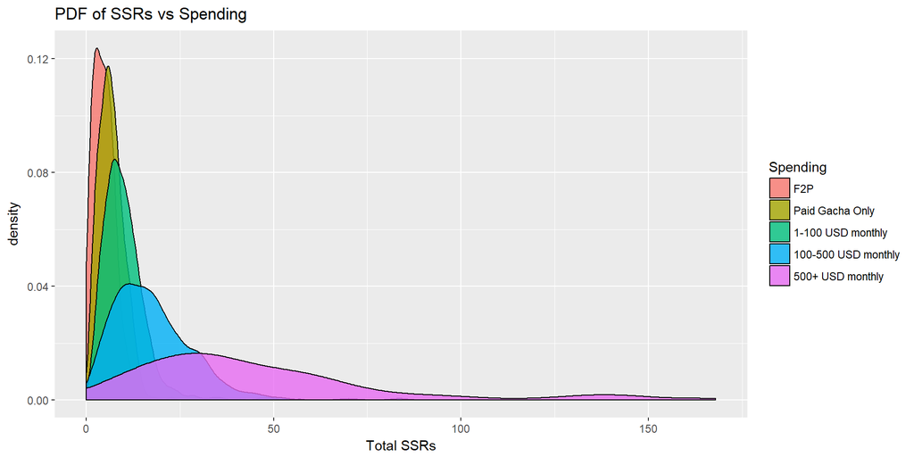

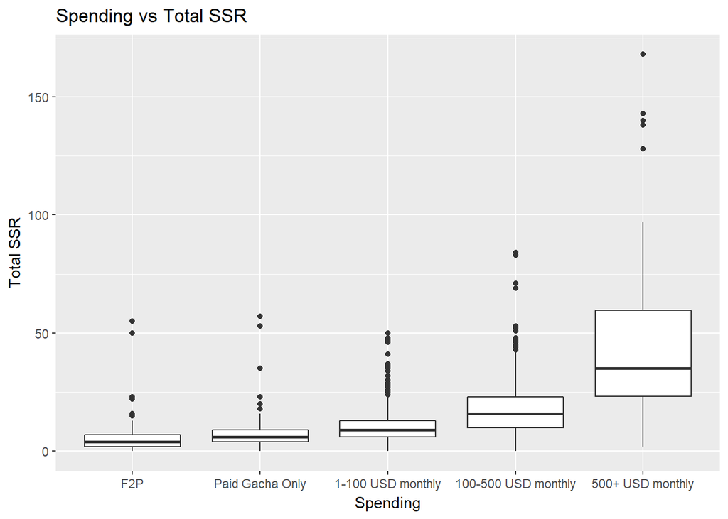

From the boxplot, there appear to be potential outliers represented as the black dots. These could be lucky players or in the case of players in the 500+ USD monthly spending category, big spenders.

### Analysis of Variance

An analysis of variance (ANOVA) can be conducted to investigate spending category and total number of SSRs.

```
##                 Df Sum Sq Mean Sq F value Pr(>F)
## data$Spending    4 183639   45910   909.4 <2e-16 ***
## Residuals     4789 241769      50
## ---
## Signif. codes:  0 '***' 0.001 '**' 0.01 '*' 0.05 '.' 0.1 ' ' 1
```

After running a one-way ANOVA using spending category as the explanatory variable, we get very strong evidence that the means of each spending category are different.

The assumptions of the ANOVA are checked via the plots below.

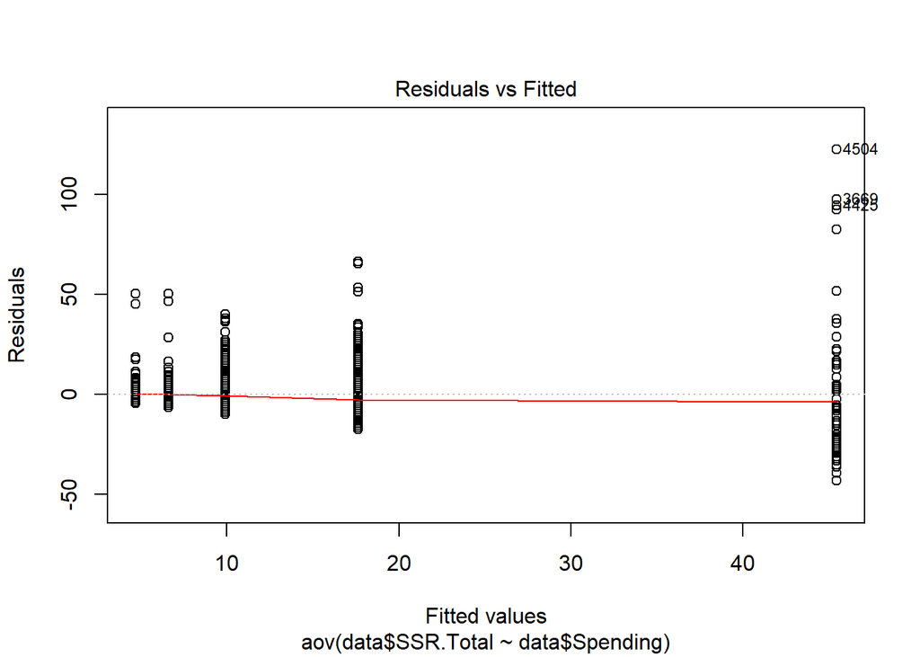

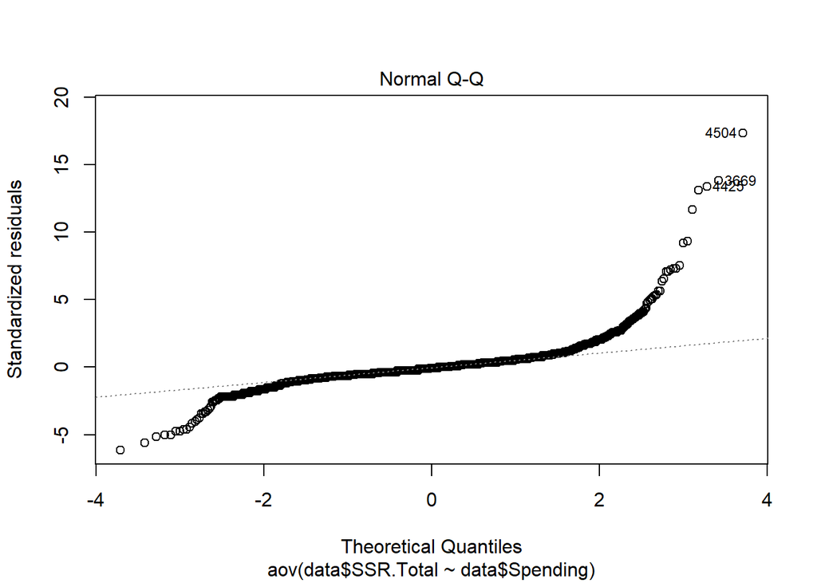

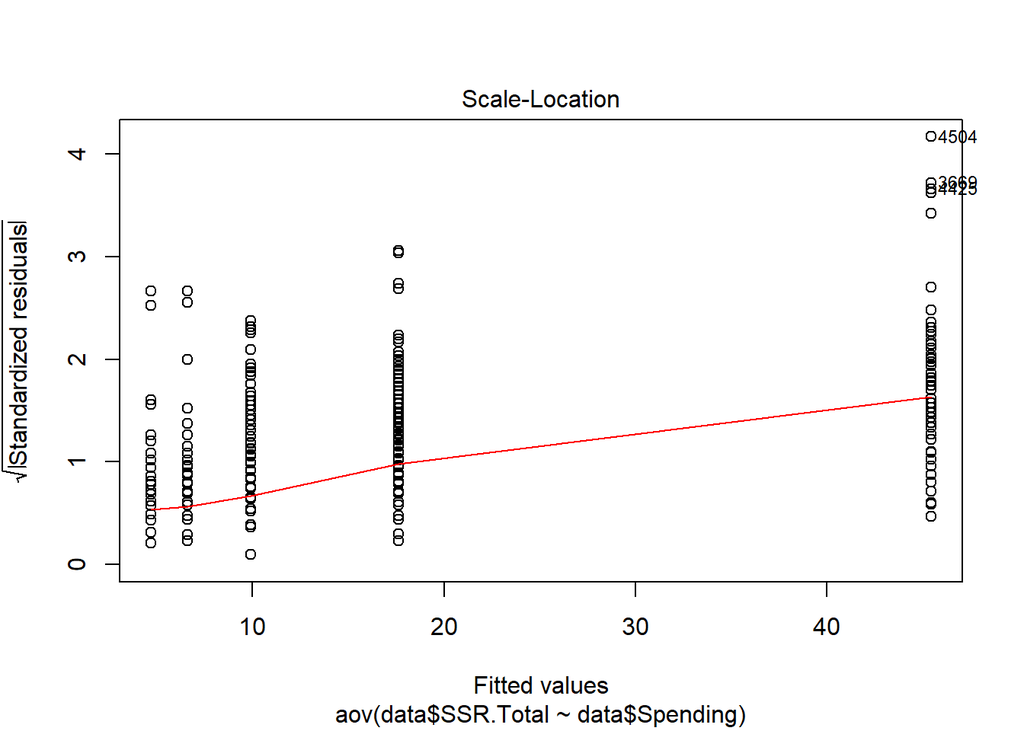

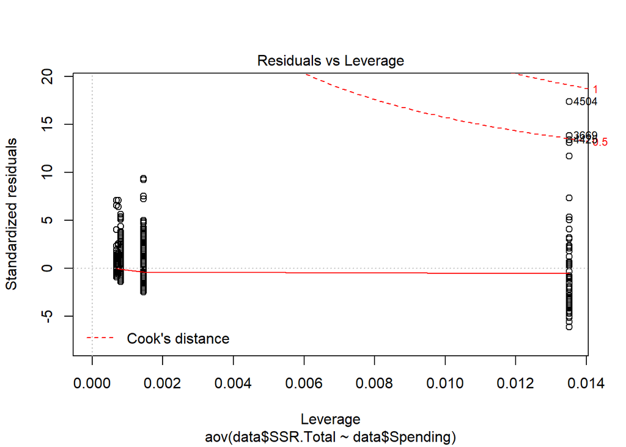

Diagnostics of the ANOVA assumptions indicate that:

- the residuals of the data may not be normally distributed via the qq-plot
- variance may not be constant by the Residuals vs Fitted plot as the group on the far right appears to have a higher variance than the other groups.

A Kruskal-Wallis test can be used instead as it makes no assumptions about the distribution (nonparametric).

```
##
##  Kruskal-Wallis rank sum test
##
## data:  SSR.Total by Spending
## Kruskal-Wallis chi-squared = 1727.3, df = 4, p-value < 2.2e-16
```

The test also indicates there is strong evidence that the means of total SSRs of the spending categories are different. To identify which spending categories are statistically different, the Games-Howell post-hoc test was used. The Games-Howell test was used instead of Tukey because it does not assume equal variences and sample size.

```
##                        n means variances
## F2P                 1341   4.7        12
## Paid Gacha Only     1451   6.6        14
## 1-100 USD monthly   1238   9.9        32
## 100-500 USD monthly  690  17.6       116
## 500+ USD monthly      74  45.4      1152
##
##                                       diff ci.lo ci.hi    t   df    p
## Paid Gacha Only-F2P                    1.9   1.5   2.3 13.9 2790 <.01
## 1-100 USD monthly-F2P                  5.2   4.7   5.7 27.8 2023 <.01
## 100-500 USD monthly-F2P               12.9  11.8  14.1 30.7  765 <.01
## 500+ USD monthly-F2P                  40.7  29.7  51.8 10.3   73 <.01
## 1-100 USD monthly-Paid Gacha Only      3.3   2.8   3.8 17.4 2095 <.01
## 100-500 USD monthly-Paid Gacha Only   11.0   9.9  12.2 26.0  771 <.01
## 500+ USD monthly-Paid Gacha Only      38.8  27.8  49.9  9.8   73 <.01
## 100-500 USD monthly-1-100 USD monthly  7.7   6.5   8.9 17.4  908 <.01
## 500+ USD monthly-1-100 USD monthly    35.5  24.5  46.5  9.0   73 <.01
## 500+ USD monthly-100-500 USD monthly  27.8  16.7  38.9  7.0   75 <.01
```

From the outputs, all pairwise comparisons are statistically different with p-values < 0.01. Thus, all spending groups have different means in SSR total.

## Unique SSRs

Unique SSRs are measured by having at least one of a SSR servant. Consequently, any additional copies of those servants are not counted e.g. NP2 Artoria will only count once for that person. This was measured by extracting and counting the relevant servants.

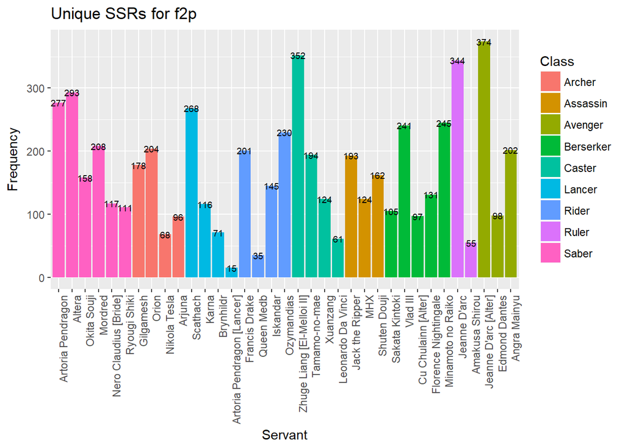

[figure not shown]

[figure not shown]

[figure not shown]

[figure not shown]

### Class Breakdown

Below is the class breakdown for each spending category. None represents no SSR for a given class.

Table 12: Saber Class Across Spending Category

| Servants | F2P | Paid.Gacha.Only | 1-100.USD.monthly | 100-500.USD.monthly | 500.USD.monthly |
| --- | --- | --- | --- | --- | --- |
| Artoria Pendragon | 277 | 56 | 478 | 406 | 389 |
| Altera | 293 | 60 | 456 | 427 | 370 |
| Okita Souji | 158 | 41 | 302 | 232 | 254 |
| Mordred | 208 | 48 | 314 | 214 | 259 |
| Nero Claudius [Bride] | 117 | 46 | 222 | 148 | 262 |
| Ryougi Shiki | 111 | 45 | 166 | 108 | 171 |
| None | 567 | 482 | 262 | 83 | 3 |

Table 13: Archer Class Across Spending Category

| Servants | F2P | Paid Gacha Only | 1-100 USD monthly | 100-500 USD monthly | 500+ USD monthly |
| --- | --- | --- | --- | --- | --- |
| Gilgamesh | 178 | 47 | 271 | 230 | 278 |
| Orion | 204 | 54 | 380 | 284 | 328 |
| Nikola Tesla | 68 | 42 | 178 | 122 | 159 |
| Arjuna | 96 | 36 | 148 | 137 | 162 |
| None | 881 | 828 | 529 | 165 | 3 |

Table 14: Lancer Class Across Spending Category

| Servants | F2P | Paid Gacha Only | 1-100 USD monthly | 100-500 USD monthly | 500+ USD monthly |
| --- | --- | --- | --- | --- | --- |
| Scathach | 268 | 65 | 425 | 323 | 407 |
| Karna | 116 | 41 | 194 | 146 | 184 |
| Brynhildr | 71 | 40 | 138 | 91 | 163 |
| Artoria Pendragon [Lancer] | 15 | 8 | 49 | 41 | 30 |
| None | 908 | 921 | 574 | 172 | 6 |

Table 15: Rider Class Across Spending Category

| Servants | F2P | Paid Gacha Only | 1-100 USD monthly | 100-500 USD monthly | 500+ USD monthly |
| --- | --- | --- | --- | --- | --- |
| Francis Drake | 201 | 51 | 425 | 378 | 337 |
| Queen Medb | 35 | 34 | 150 | 139 | 124 |
| Iskandar | 145 | 38 | 198 | 154 | 174 |
| Ozymandias | 230 | 54 | 413 | 334 | 334 |
| None | 833 | 657 | 403 | 124 | 2 |

Table 16: Caster Class Across Spending Category

| Servants | F2P | Paid Gacha Only | 1-100 USD monthly | 100-500 USD monthly | 500+ USD monthly |
| --- | --- | --- | --- | --- | --- |
| Zhuge Liang [El-Melloi II] | 352 | 64 | 598 | 561 | 441 |
| Tamamo-no-mae | 194 | 58 | 464 | 361 | 389 |
| Xuanzang | 124 | 54 | 294 | 265 | 289 |
| Leonardo Da Vinci | 61 | 37 | 103 | 51 | 123 |
| None | 754 | 526 | 289 | 81 | 0 |

Table 17: Assassin Class Across Spending Category

| Servants | F2P | Paid Gacha Only | 1-100 USD monthly | 100-500 USD monthly | 500+ USD monthly |
| --- | --- | --- | --- | --- | --- |
| Jack the Ripper | 193 | 57 | 423 | 298 | 343 |
| MHX | 124 | 44 | 209 | 132 | 224 |
| Shuten Douji | 162 | 48 | 280 | 153 | 268 |
| None | 916 | 950 | 546 | 163 | 5 |

Table 18: Berserker Class Across Spending Category

| Servants | F2P | Paid Gacha Only | 1-100 USD monthly | 100-500 USD monthly | 500+ USD monthly |
| --- | --- | --- | --- | --- | --- |
| Sakata Kintoki | 105 | 35 | 148 | 103 | 150 |
| Vlad III | 241 | 56 | 465 | 414 | 374 |
| Cu Chulainn [Alter] | 97 | 45 | 258 | 236 | 235 |
| Florence Nightingale | 131 | 41 | 277 | 206 | 215 |
| Minamoto no Raiko | 245 | 60 | 373 | 263 | 387 |
| None | 701 | 573 | 301 | 73 | 2 |

Table 19: Ruler Class Across Spending Category

| Servants | F2P | Paid Gacha Only | 1-100 USD monthly | 100-500 USD monthly | 500+ USD monthly |
| --- | --- | --- | --- | --- | --- |
| Jeanne D’arc | 344 | 67 | 561 | 450 | 396 |
| Amakusa Shirou | 55 | 35 | 97 | 59 | 94 |
| None | 958 | 952 | 621 | 261 | 6 |

Table 20: Avenger Class Across Spending Category

| Servants | F2P | Paid Gacha Only | 1-100 USD monthly | 100-500 USD monthly | 500+ USD monthly |
| --- | --- | --- | --- | --- | --- |
| Jeanne D’arc [Alter] | 374 | 68 | 586 | 498 | 473 |
| Edmond Dantes | 98 | 25 | 128 | 65 | 98 |
| Angra Mainyu | 202 | 34 | 277 | 278 | 199 |
| None | 778 | 749 | 469 | 157 | 3 |

### Most Common Unique SSRs

| Servants | Total |
| --- | --- |
| Zhuge Liang [El-Melloi II] | 2016 |
| Jeanne D’arc [Alter] | 1999 |
| Jeanne D’arc | 1818 |
| Altera | 1606 |
| Artoria Pendragon | 1606 |
| Vlad III | 1550 |
| Scathach | 1488 |
| Tamamo-no-mae | 1466 |
| Francis Drake | 1392 |
| Ozymandias | 1365 |
| Minamoto no Raiko | 1328 |
| Jack the Ripper | 1314 |
| Orion | 1250 |
| Mordred | 1043 |
| Xuanzang | 1026 |
| Gilgamesh | 1004 |
| Angra Mainyu | 990 |
| Okita Souji | 987 |
| Shuten Douji | 911 |
| Cu Chulainn [Alter] | 871 |
| Florence Nightingale | 870 |
| Nero Claudius [Bride] | 795 |
| MHX | 733 |
| Iskandar | 709 |
| Karna | 681 |
| Ryougi Shiki | 601 |
| Arjuna | 579 |
| Nikola Tesla | 569 |
| Sakata Kintoki | 541 |
| Brynhildr | 503 |
| Queen Medb | 482 |
| Edmond Dantes | 414 |
| Leonardo Da Vinci | 375 |
| Amakusa Shirou | 340 |
| Artoria Pendragon [Lancer] | 143 |

From the table, we can see that the top five most common SSRs are:

1. Zhung Liang [El-Melloi II]
2. Jeanne D’arc [Alter]
3. Jean D’arc
4. Altera
5. Artoria Pendragon

Conversly, the top five least common SSRs are:

1. Artoria Pendragon [Lancer]
2. Amakusa Shirou
3. Leonardo Da Vinci
4. Edmond Dantes
5. Queen Medb